# course project V2

Samir N. Hag Ibrahim

8/6/2020

# Loading Required Packages

```r
suppressMessages(library(caret))
suppressMessages(library(gbm))
suppressMessages(library(randomForest))
```

# Loading Data

```r
train <- read.csv("https://d396qusza40orc.cloudfront.net/predmachlearn/pml-training.csv")
test <- read.csv("https://d396qusza40orc.cloudfront.net/predmachlearn/pml-testing.csv")
```

# Data Processing and Partitioning

Now, checking missing values

```r
missing.data <- c() # creat empty container to capture results from the function
for (i in names(train)) {
        missing <- sum((is.na(train[, i]))| train[, i] == "")
        if (missing > 0.80*nrow(train)) { # if missing data is more than 80% of the no. of rows
                missing.data[i] <- which(colnames(train) == i) # then store the variable "i" and store the number of missings
        }
}
length(missing.data)
```

```
## [1] 100
```

or, simply

```r
missing.data <- which(colSums(is.na(train) | train == "")>0.8*nrow(train))
length(missing.data)
```

```
## [1] 100
```

there are missing data in 100 variable out of the 160. we can use zero and near-zero variance function to eliminate variables with zero variance (i.e. containing zero entropy or information).

```r
data.nzv <- nearZeroVar(train, saveMetrics = TRUE) # save matrix to see
data.nzv <- which(data.nzv$zeroVar == "TRUE" | data.nzv$nzv == "TRUE")
length(data.nzv)
```

```
## [1] 60
```

see whether all 60 low variance variables are within the 100 missing data

```r
length(intersect(missing.data, data.nzv))
```

```
## [1] 59
```

Almost all except 1, to know which one

```r
cname <- setdiff(data.nzv, missing.data) # in data.nzv but not in missing.data
colnames(train[cname])
```

```
## [1] "new_window"
```

```r
var(train[,cname])
```

```
## [1] 0.02026397
```

Then need to remove columns from 1:7 (id columns), and all the missing data columns.

```r
train <- train[ , -missing.data]
train <- train[,-c(1:7)]
dim(train)
```

```
## [1] 19622    53
```

now in total 107 column was removed.

we will remove the same variables from the test data.

```r
test <- test[ , -missing.data]
test <- test[,-c(1:7)]
test <-  test[,-53]
dim(test)
```

```
## [1] 20 52
```

## Data transformation

```r
# transforming trainin data set
train.trans <-preProcess(train, method = c("scale", "center"))
train <- predict(train.trans, newdata = train)

# transforming test data set
test.trans <-preProcess(test, method = c("scale", "center"))
test <- predict(test.trans, newdata = test)
```

The training set will be splitted into two set: train and validate, while leaving the test set the final model evaluation.Before partitioning the train data set we need to evaluate class imbalance in the data set.

```r
table(train$classe)
```

```
##
##    A    B    C    D    E
## 5580 3797 3422 3216 3607
```

we see class “A” is little more weigthed, butwe don’t need to handle such little difference. So, we will partition the train dataset.

```r
# partitioning the data into 70% training and 30% validation
inTrain <- createDataPartition(train$classe, p=0.7, list = FALSE)
validate <- train[-inTrain, ]
train <- train[inTrain, ]
dim(train);dim(validate)
```

```
## [1] 13737    53
```

```
## [1] 5885   53
```

# Data Exploration and Preparation

Find relationship between variables

```r
corMatrix <- cor(train[,-53])
cor.var <- findCorrelation(corMatrix, cutoff = 0.8, name = TRUE) #0.8 correlation threashold
cor.var
```

```
##  [1] "accel_belt_z"     "roll_belt"        "accel_belt_y"
##  [4] "accel_dumbbell_z" "accel_belt_x"     "pitch_belt"
##  [7] "accel_arm_x"      "accel_dumbbell_x" "magnet_arm_y"
## [10] "gyros_forearm_y"  "gyros_dumbbell_x" "gyros_dumbbell_z"
## [13] "gyros_arm_x"
```

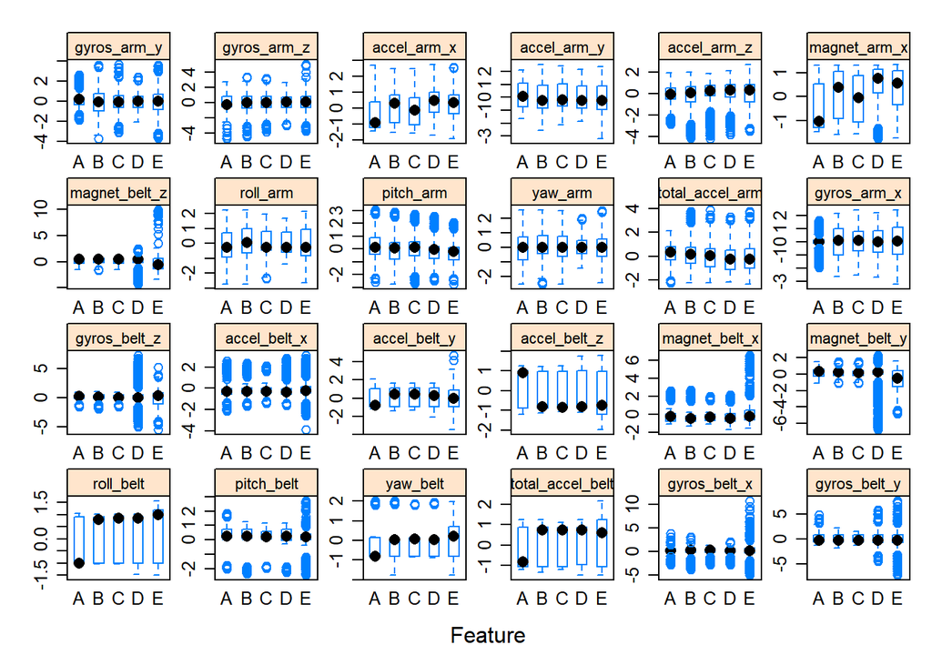

```r
featurePlot(x =train[,1:24],
            y = train$classe,
            plot = "box",
            strip=strip.custom(par.strip.text=list(cex=.7)),
            scales = list(x = list(relation="free"),
                          y = list(relation="free")))
```

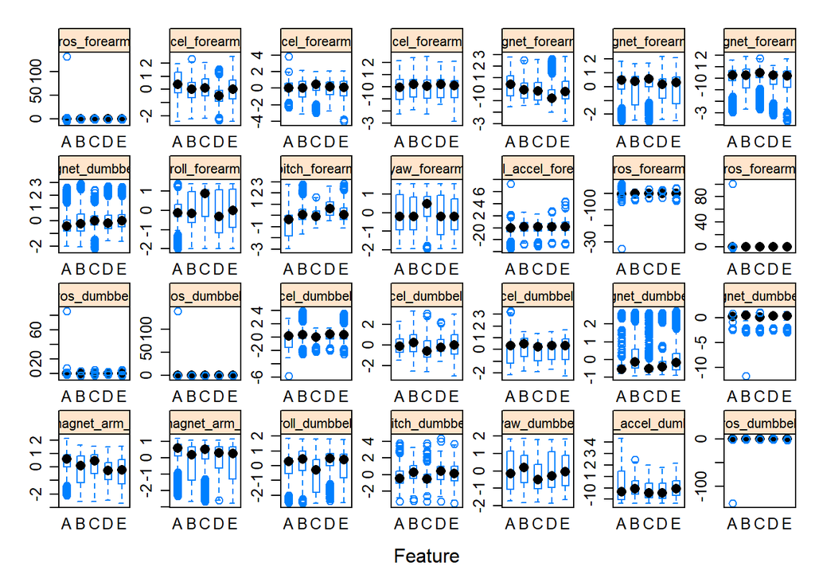

```r
featurePlot(x =train[,25:52],
            y = train$classe,
            plot = "box",
            strip=strip.custom(par.strip.text=list(cex=.7)),
            scales = list(x = list(relation="free"),
                          y = list(relation="free")))
```